# Exploration

C. Coleman

10/13/2021

## This document will serve as the exploration for Module 8. As indicated, the outcomes of interests are “Body Temperature” and “Nausea”.

*Let’s start by loading needed libraries.*

*Now, lets load out cleaned data.*

```r
clean_df_location <- here::here("data", "processed_data", "processeddata.RDS")

clean_df <- readRDS(clean_df_location)
```

*As good practice, let’s summarize and take a look at clean_df.*

```r
summary(clean_df)
```

```
##  SwollenLymphNodes ChestCongestion ChillsSweats NasalCongestion CoughYN
##  No :418           No :323         No :130      No :167         No : 75
##  Yes:312           Yes:407         Yes:600      Yes:563         Yes:655
##
##
##
##
##  Sneeze    Fatigue   SubjectiveFever Headache      Weakness   WeaknessYN
##  No :339   No : 64   No :230         No :115   None    : 49   No : 49
##  Yes:391   Yes:666   Yes:500         Yes:615   Mild    :223   Yes:681
##                                                Moderate:338
##                                                Severe  :120
##
##
##   CoughIntensity CoughYN2      Myalgia    MyalgiaYN RunnyNose AbPain
##  None    : 47    No : 47   None    : 79   No : 79   No :211   No :639
##  Mild    :154    Yes:683   Mild    :213   Yes:651   Yes:519   Yes: 91
##  Moderate:357              Moderate:325
##  Severe  :172              Severe  :113
##
##
##  ChestPain Diarrhea  EyePn     Insomnia  ItchyEye  Nausea    EarPn
##  No :497   No :631   No :617   No :315   No :551   No :475   No :568
##  Yes:233   Yes: 99   Yes:113   Yes:415   Yes:179   Yes:255   Yes:162
##
##
##
##
##  Hearing   Pharyngitis Breathless ToothPn   Vision    Vomit     Wheeze
##  No :700   No :119     No :436    No :565   No :711   No :652   No :510
##  Yes: 30   Yes:611     Yes:294    Yes:165   Yes: 19   Yes: 78   Yes:220
##
##
##
##
##     BodyTemp
##  Min.   : 97.20
##  1st Qu.: 98.20
##  Median : 98.50
##  Mean   : 98.94
##  3rd Qu.: 99.30
##  Max.   :103.10
```

```r
glimpse(clean_df)
```

```
## Rows: 730
## Columns: 32
## $ SwollenLymphNodes <fct> Yes, Yes, Yes, Yes, Yes, No, No, No, Yes, No, Yes, Y~
## $ ChestCongestion   <fct> No, Yes, Yes, Yes, No, No, No, Yes, Yes, Yes, Yes, Y~
## $ ChillsSweats      <fct> No, No, Yes, Yes, Yes, Yes, Yes, Yes, Yes, No, Yes, ~
## $ NasalCongestion   <fct> No, Yes, Yes, Yes, No, No, No, Yes, Yes, Yes, Yes, Y~
## $ CoughYN           <fct> Yes, Yes, No, Yes, No, Yes, Yes, Yes, Yes, Yes, No, ~
## $ Sneeze            <fct> No, No, Yes, Yes, No, Yes, No, Yes, No, No, No, No, ~
## $ Fatigue           <fct> Yes, Yes, Yes, Yes, Yes, Yes, Yes, Yes, Yes, Yes, Ye~
## $ SubjectiveFever   <fct> Yes, Yes, Yes, Yes, Yes, Yes, Yes, Yes, Yes, No, Yes~
## $ Headache          <fct> Yes, Yes, Yes, Yes, Yes, Yes, No, Yes, Yes, Yes, Yes~
## $ Weakness          <fct> Mild, Severe, Severe, Severe, Moderate, Moderate, Mi~
## $ WeaknessYN        <fct> Yes, Yes, Yes, Yes, Yes, Yes, Yes, Yes, Yes, Yes, Ye~
## $ CoughIntensity    <fct> Severe, Severe, Mild, Moderate, None, Moderate, Seve~
## $ CoughYN2          <fct> Yes, Yes, Yes, Yes, No, Yes, Yes, Yes, Yes, Yes, Yes~
```

[output cut: 19 more lines]

```r
view(clean_df)
```

```
## x must either be a summarytools object created with freq(), descr(), or a list of summarytools objects created using by()
```

#### Now, we are going to create a new df for variables we want to explore. First, our outcomes are determined to be “Nausea” and “Body Temperature”. That is to say, we want to assess what what other symptoms may be related to either presence of nausea or changes body temperature. Best on the data, I think it would be interesting to split the data into gastro intestinal (GI) associated symptoms and body temp/fever associated symptoms. Additionally, I want to include patient perceived data to see how well they indicate either a change in body temperature or presence of nausea. Additionally, I want to throw in the symptoms tooth pain and itchy eyes just for fun to see if their is any correlation between presenting in nausea or change in body temperature and having one of the other symptoms. This will just be a little extra on the side, seeing as nausea and body temperature will no longer be the outcomes.

#### The variables of interest are as follows: GI (Nausea as outcome): Nausea, Ab Pain, Diarrhea, Vomit.

#### Fever symptoms (Body Temperature as outcome): body temp, weakness(Y/N), subjective fever, fatigue, chills/sweats.

#### Others: itchy eyes, tooth pain.

*Creating a df of selected variables and calling it “exploration_df”.*

```r
exploration_df <- clean_df %>%
  select("ChillsSweats", "Fatigue", "SubjectiveFever", "WeaknessYN", "AbPain", "Diarrhea", "ItchyEye", "Nausea", "ToothPn", "Vomit", "BodyTemp")
```

*At this point, it is useful to create a summary table for the variables chosen. Since most of the variables are Y/N, this table will show relative proportions of presence/absence of symptoms in ths data set*

```r
summary_stats <- dfSummary(exploration_df, plain.ascii = FALSE, style = "grid")

print(summary_stats, method = 'render')
```

Data Frame Summary

exploration_df

**Dimensions**: 730 x 11  
**Duplicates**: 200

| **No** | **Variable** | **Stats / Values** | **Freqs (% of Valid)** | **Graph** | **Valid** | **Missing** |
| --- | --- | --- | --- | --- | --- | --- |
| 1 | ChillsSweats [factor] | 1. No 2. Yes | 130 ( 17.8% ) 600 ( 82.2% ) |  | 730 (100.0%) | 0 (0.0%) |
| 2 | Fatigue [factor] | 1. No 2. Yes | 64 ( 8.8% ) 666 ( 91.2% ) |  | 730 (100.0%) | 0 (0.0%) |
| 3 | SubjectiveFever [factor] | 1. No 2. Yes | 230 ( 31.5% ) 500 ( 68.5% ) |  | 730 (100.0%) | 0 (0.0%) |
| 4 | WeaknessYN [factor] | 1. No 2. Yes | 49 ( 6.7% ) 681 ( 93.3% ) |  | 730 (100.0%) | 0 (0.0%) |
| 5 | AbPain [factor] | 1. No 2. Yes | 639 ( 87.5% ) 91 ( 12.5% ) |  | 730 (100.0%) | 0 (0.0%) |
| 6 | Diarrhea [factor] | 1. No 2. Yes | 631 ( 86.4% ) 99 ( 13.6% ) |  | 730 (100.0%) | 0 (0.0%) |
| 7 | ItchyEye [factor] | 1. No 2. Yes | 551 ( 75.5% ) 179 ( 24.5% ) |  | 730 (100.0%) | 0 (0.0%) |
| 8 | Nausea [factor] | 1. No 2. Yes | 475 ( 65.1% ) 255 ( 34.9% ) |  | 730 (100.0%) | 0 (0.0%) |
| 9 | ToothPn [factor] | 1. No 2. Yes | 565 ( 77.4% ) 165 ( 22.6% ) |  | 730 (100.0%) | 0 (0.0%) |
| 10 | Vomit [factor] | 1. No 2. Yes | 652 ( 89.3% ) 78 ( 10.7% ) |  | 730 (100.0%) | 0 (0.0%) |
| 11 | BodyTemp [numeric] | Mean (sd) : 98.9 (1.2) min ≤ med ≤ max: 97.2 ≤ 98.5 ≤ 103.1 IQR (CV) : 1.1 (0) | 57 distinct values |  | 730 (100.0%) | 0 (0.0%) |

Generated by summarytools 1.0.0 ([R](https://www.r-project.org/) version 4.1.1)  
2021-10-14

#### At this point, we are just going to start plotting and visualizing data. This will give us an idea of what symptoms are most common and ones that are most rare. This will set the stage for determineing what symptoms tend to occur together.

*Below is a bar plot of presence/absence of Nausea*

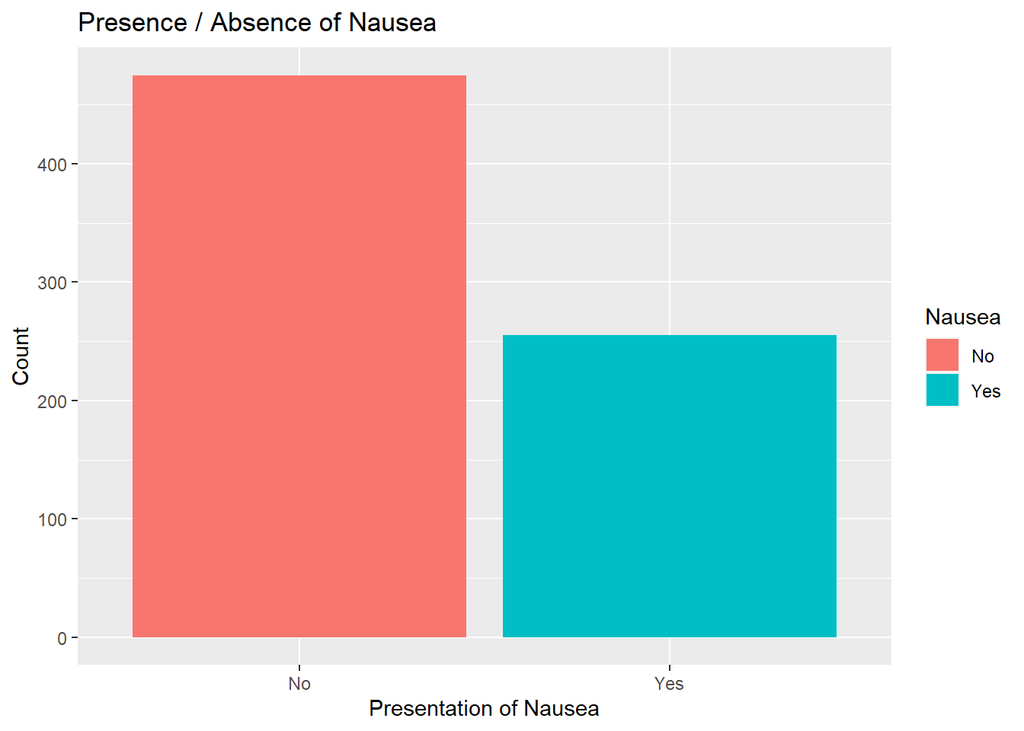

```r
nausea_plot <- ggplot(data=exploration_df, aes(x=Nausea, fill=Nausea)) + geom_bar() +
labs(title= "Presence / Absence of Nausea") + xlab("Presentation of Nausea") +  ylab("Count")

print(nausea_plot)
```

*Below is a histogram of recorded Body Temperatures*

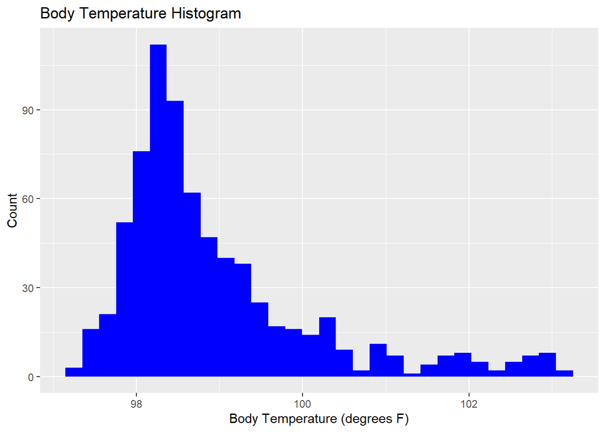

```r
BodyTemp_plot <- ggplot(data=exploration_df, aes(x=BodyTemp)) + geom_histogram(fill="blue") + labs(title= "Body Temperature Histogram") + xlab("Body Temperature (degrees F)") +  ylab("Count")

print(BodyTemp_plot)
```

*Below is a bar plot of presence/absence of Chills/Sweat*

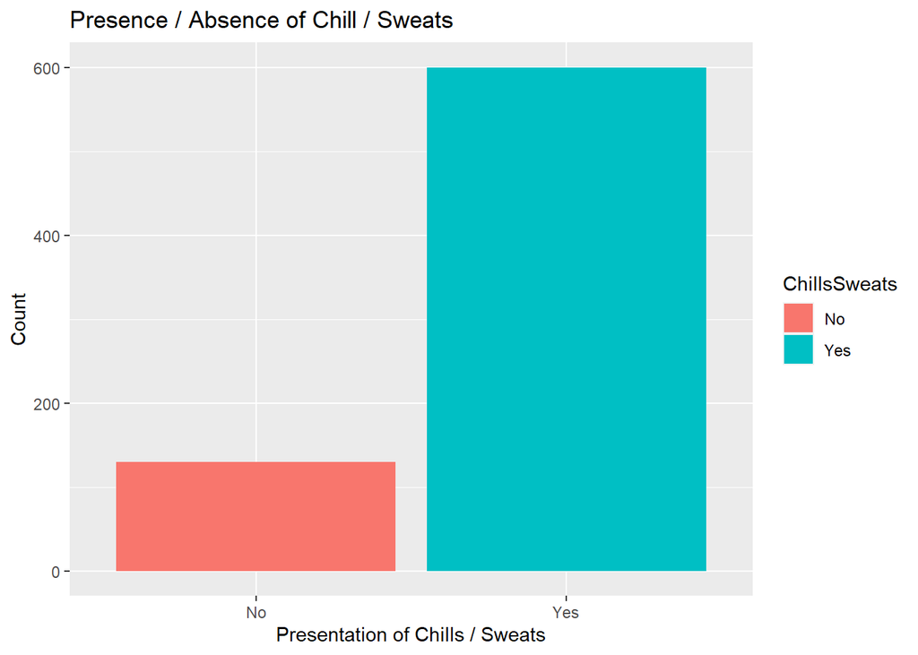

```r
chillsweat_plot <- ggplot(data=exploration_df, aes(x=ChillsSweats, fill=ChillsSweats)) + geom_bar() +
labs(title= "Presence / Absence of Chill / Sweats") + xlab("Presentation of Chills / Sweats") +  ylab("Count")

print(chillsweat_plot)
```

*Below is a bar plot of presence/absence of Fatigue*

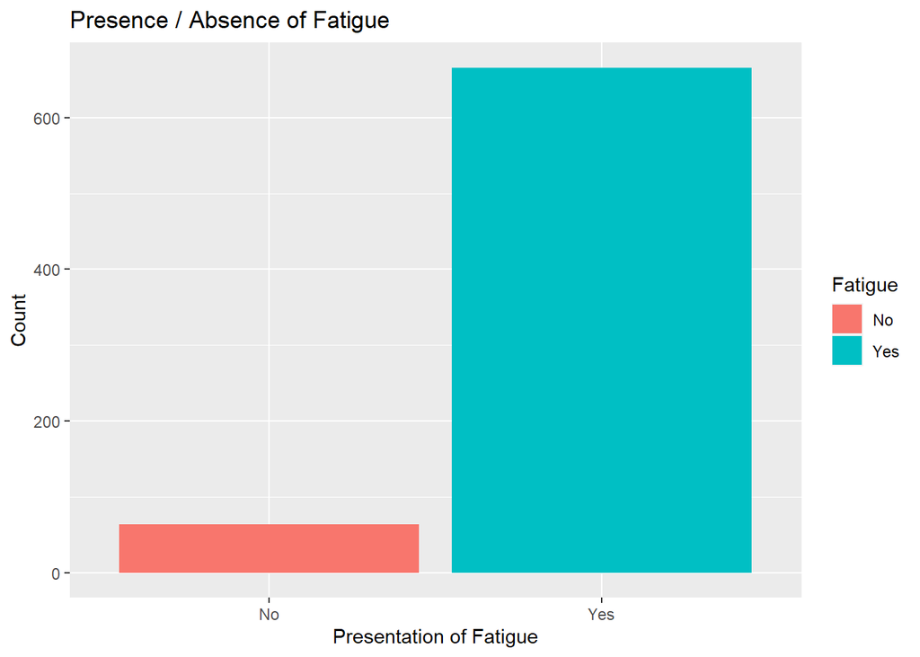

```r
fatigue_plot <- ggplot(data=exploration_df, aes(x=Fatigue, fill=Fatigue)) + geom_bar() +
labs(title= "Presence / Absence of Fatigue") + xlab("Presentation of Fatigue") +  ylab("Count")

print(fatigue_plot)
```

*Below is a bar plot of presence/absence of Subjective Fever*

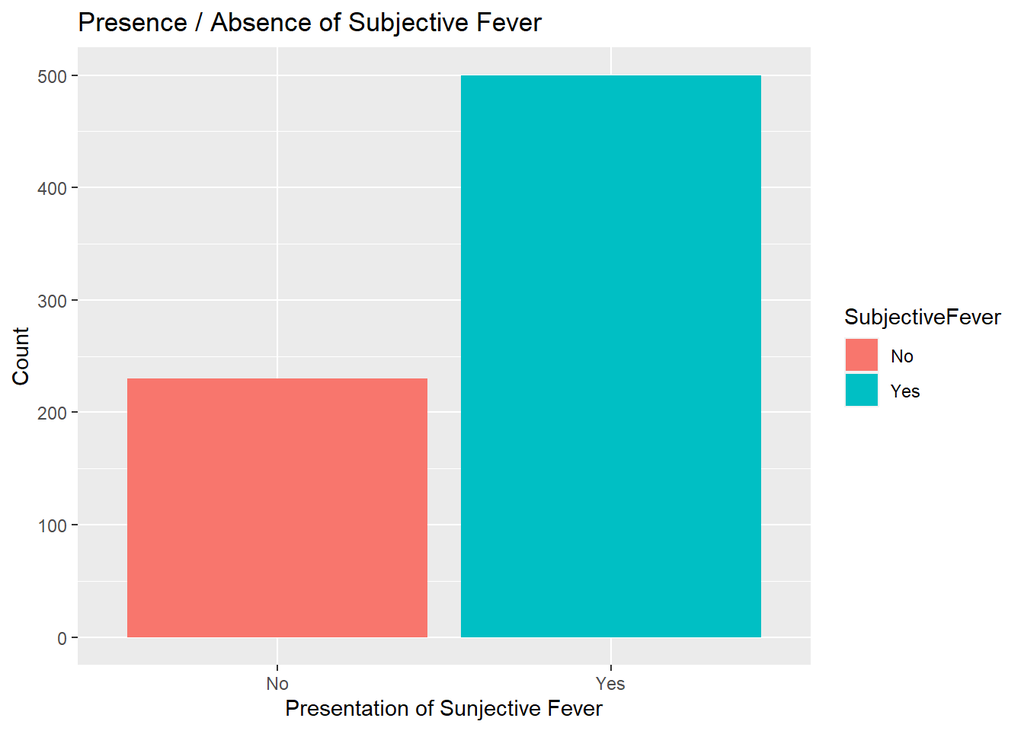

```r
SubFever_plot <- ggplot(data=exploration_df, aes(x=SubjectiveFever, fill=SubjectiveFever)) + geom_bar() +
labs(title= "Presence / Absence of Subjective Fever") + xlab("Presentation of Sunjective Fever") +  ylab("Count")

print(SubFever_plot)
```

*Below is a bar plot of presence/absence of Weakness*

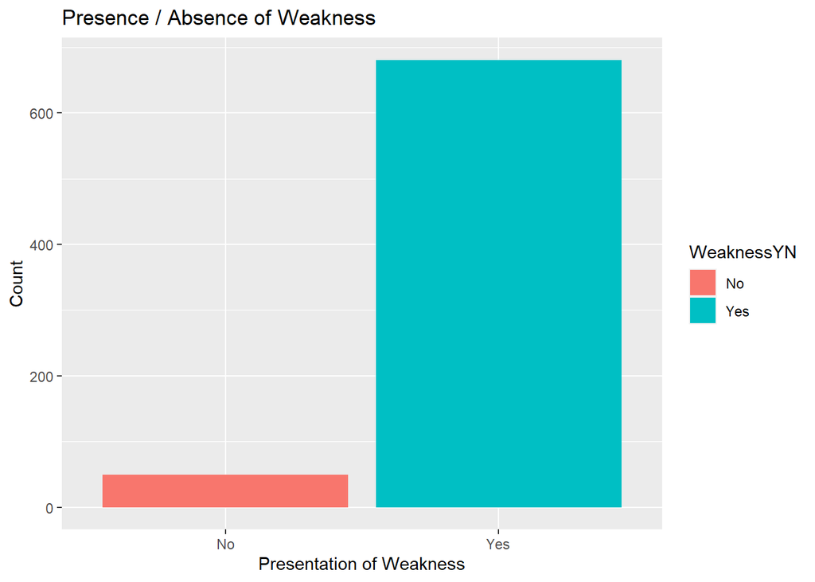

```r
weakness_plot <- ggplot(data=exploration_df, aes(x=WeaknessYN, fill=WeaknessYN)) + geom_bar() +
labs(title= "Presence / Absence of Weakness") + xlab("Presentation of Weakness") +  ylab("Count")

print(weakness_plot)
```

*Below is a bar plot of presence/absence of Ab Pain*

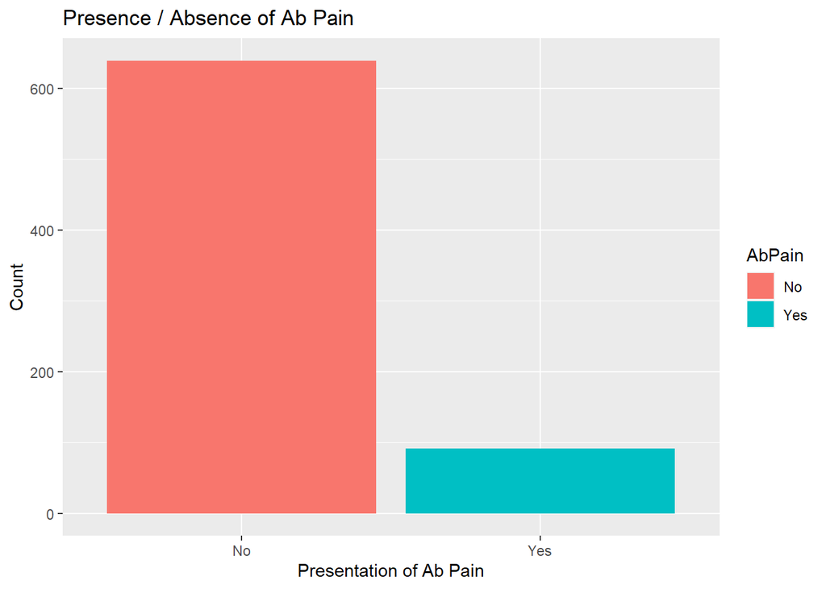

```r
AbPn_plot <- ggplot(data=exploration_df, aes(x=AbPain, fill=AbPain)) + geom_bar() +
labs(title= "Presence / Absence of Ab Pain") + xlab("Presentation of Ab Pain") +  ylab("Count")

print(AbPn_plot)
```

*Below is a bar plot of presence/absence of Itchy Eyes*

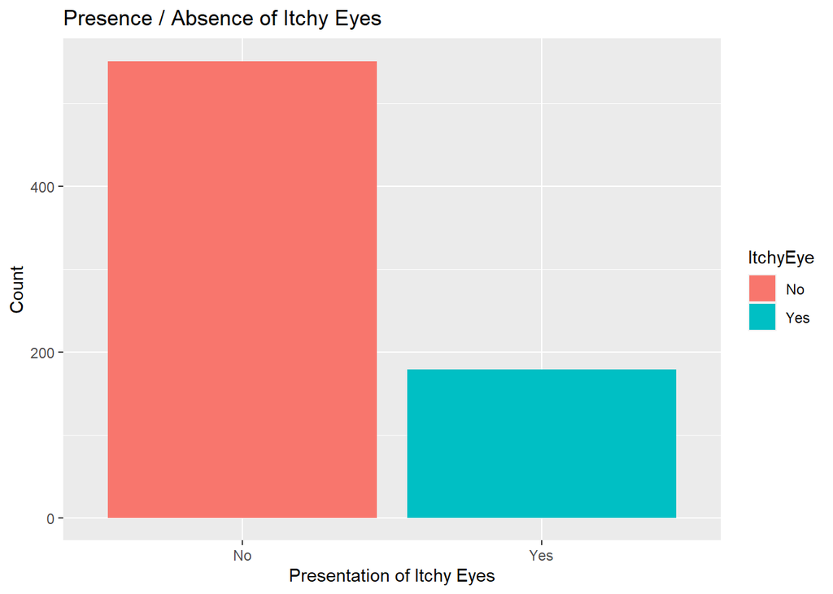

```r
ItchyEyes_plot <- ggplot(data=exploration_df, aes(x=ItchyEye, fill=ItchyEye)) + geom_bar() +
labs(title= "Presence / Absence of Itchy Eyes") + xlab("Presentation of Itchy Eyes") +  ylab("Count")

print(ItchyEyes_plot)
```

*Below is a bar plot of presence/absence of Tooth Pain*

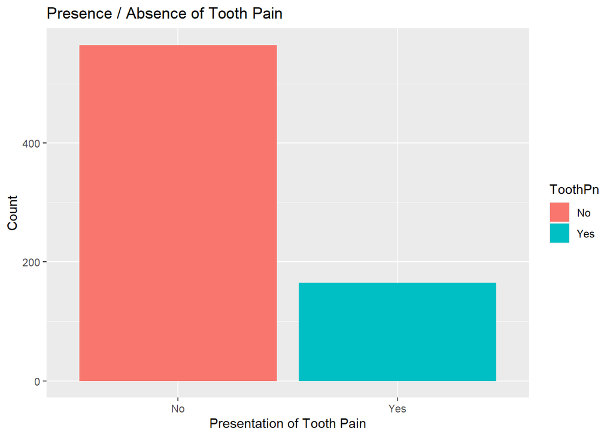

```r
Toothpain_plot <- ggplot(data=exploration_df, aes(x=ToothPn, fill=ToothPn)) + geom_bar() +
labs(title= "Presence / Absence of Tooth Pain") + xlab("Presentation of Tooth Pain") +  ylab("Count")

print(Toothpain_plot)
```

*Below is a bar plot of presence/absence of Vomit*

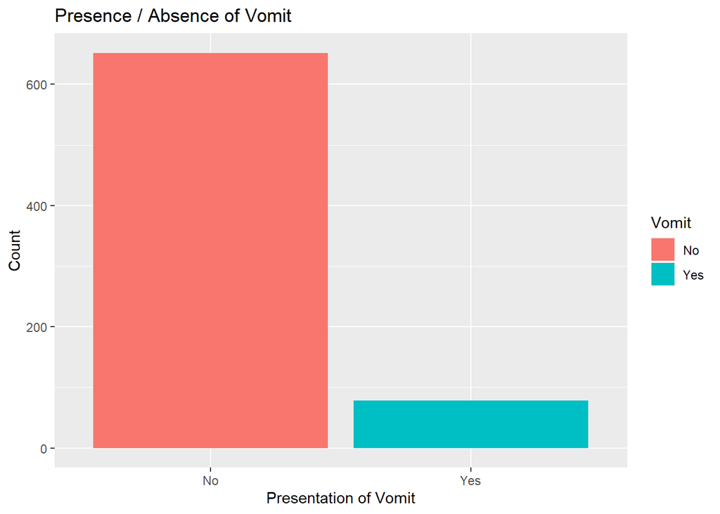

```r
Vomit_plot <- ggplot(data=exploration_df, aes(x=Vomit, fill=Vomit)) + geom_bar() +
labs(title= "Presence / Absence of Vomit") + xlab("Presentation of Vomit") +  ylab("Count")

print(Vomit_plot)
```

*Below is a bar plot of presence/absence of Diarrhea*

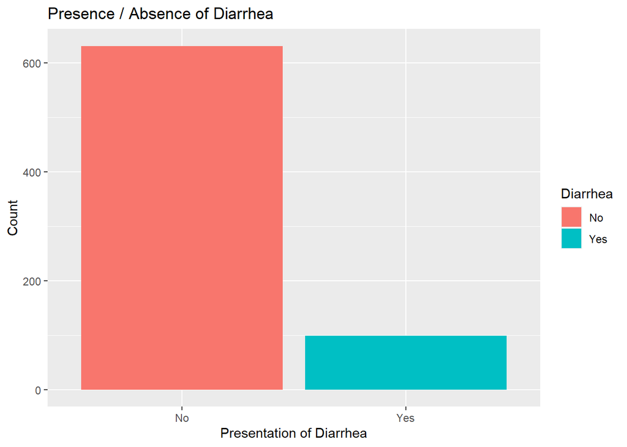

```r
Diarrhea_plot <- ggplot(data=exploration_df, aes(x=Diarrhea, fill=Diarrhea)) + geom_bar() +
labs(title= "Presence / Absence of Diarrhea") + xlab("Presentation of Diarrhea") +  ylab("Count")

print(Diarrhea_plot)
```

*Below is a box plot showing presence and absence of subjectively determined fever as a predictor to actual change in body temperature*

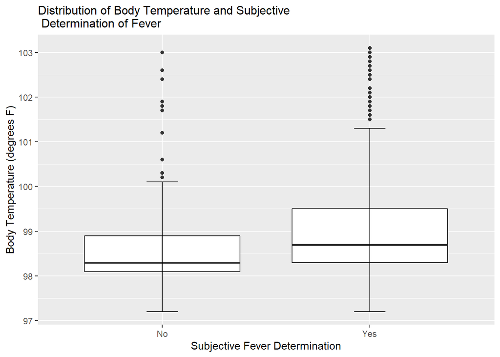

```r
subfev_bodytemp <- ggplot(exploration_df, aes(x = SubjectiveFever, y = BodyTemp)) +
  geom_boxplot() +
  ggtitle("Distribution of Body Temperature and Subjective \n Determination of Fever") +
  scale_x_discrete(name = "Subjective Fever Determination") +
  scale_y_continuous(name = "Body Temperature (degrees F)") +
  theme(plot.title = element_text(size = 12)) +
  stat_boxplot(geom = 'errorbar', width = 0.15)

print(subfev_bodytemp)
```

*Below is a box plot showing presence and absence of chills/sweats as a predictor to actual change in body temperature*

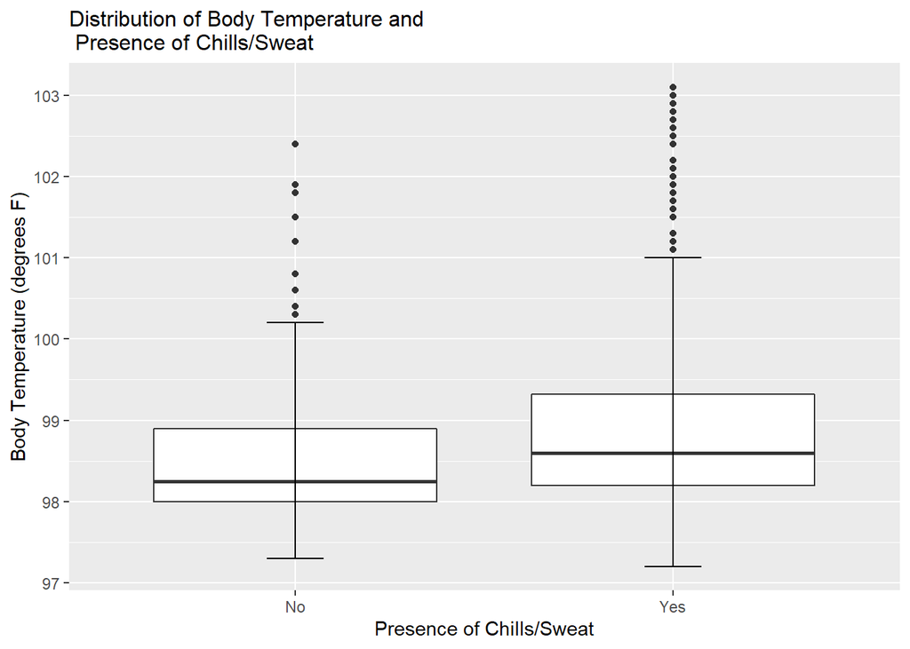

```r
CS_bodytemp <- ggplot(exploration_df, aes(x = ChillsSweats, y = BodyTemp)) +
  geom_boxplot() +
  ggtitle("Distribution of Body Temperature and \n Presence of Chills/Sweat") +
  scale_x_discrete(name = "Presence of Chills/Sweat") +
  scale_y_continuous(name = "Body Temperature (degrees F)") +
  theme(plot.title = element_text(size = 12)) +
  stat_boxplot(geom = 'errorbar', width = 0.15)

print(CS_bodytemp)
```

*Below is a box plot showing change in body temperature as a function of presence and absence of Vomit*

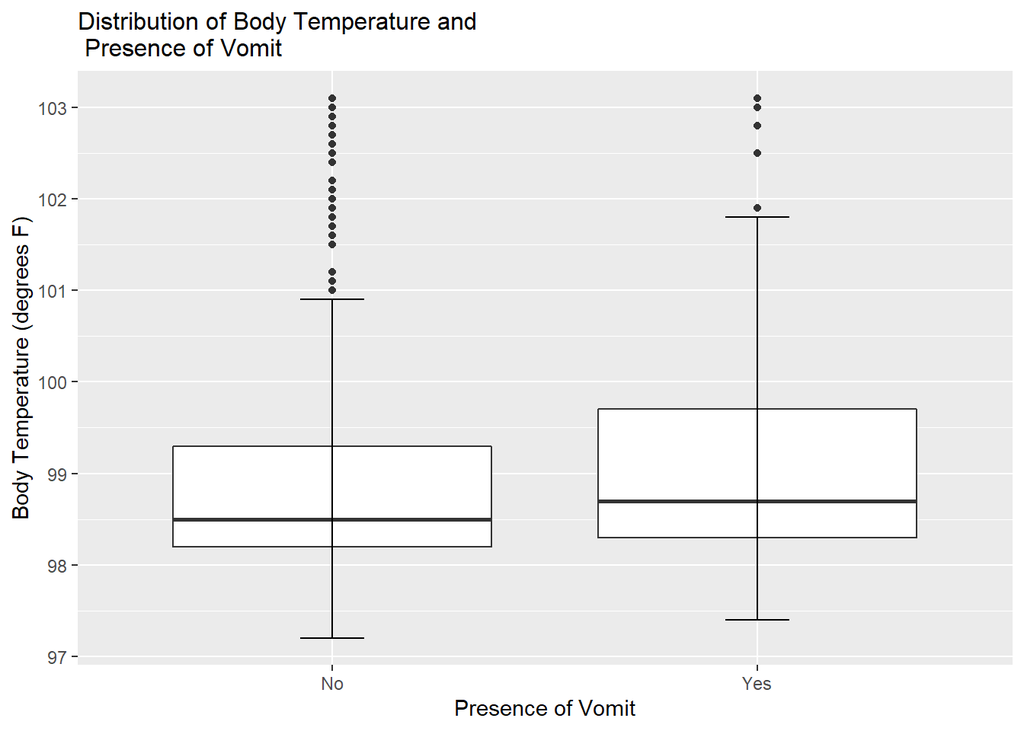

```r
vomit_bodytemp <- ggplot(exploration_df, aes(x = Vomit, y = BodyTemp)) +
  geom_boxplot() +
  ggtitle("Distribution of Body Temperature and \n Presence of Vomit") +
  scale_x_discrete(name = "Presence of Vomit") +
  scale_y_continuous(name = "Body Temperature (degrees F)") +
  theme(plot.title = element_text(size = 12)) +
  stat_boxplot(geom = 'errorbar', width = 0.15)

print(vomit_bodytemp)
```

*Once again, a similar trend as above in reference to the IQR of the presence/absence of vomiting with respect to changing body temperature.*

*Below is a box plot showing change in body temperature as a function of presence and absence of Diarrhea.*

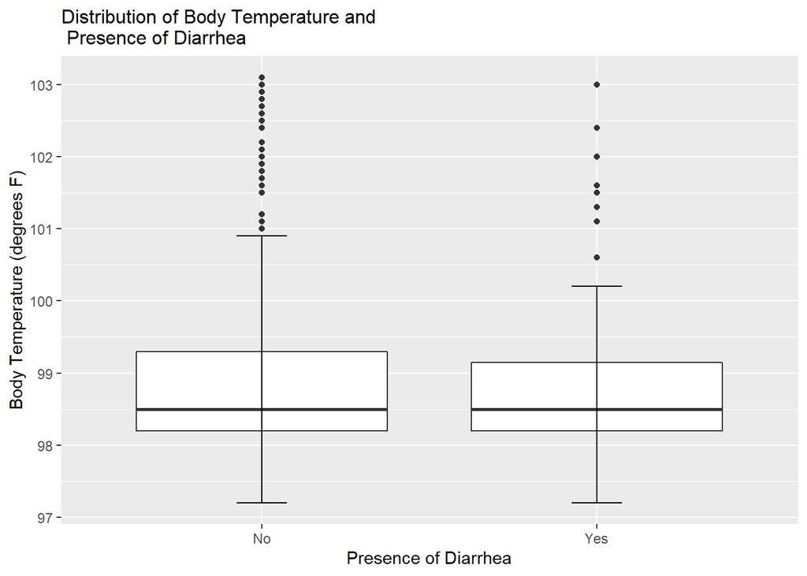

```r
diarrhea_bodytemp <- ggplot(exploration_df, aes(x = Diarrhea, y = BodyTemp)) +
  geom_boxplot() +
  ggtitle("Distribution of Body Temperature and \n Presence of Diarrhea") +
  scale_x_discrete(name = "Presence of Diarrhea") +
  scale_y_continuous(name = "Body Temperature (degrees F)") +
  theme(plot.title = element_text(size = 12)) +
  stat_boxplot(geom = 'errorbar', width = 0.15)

print(diarrhea_bodytemp)
```

*Finally, we do not see the same trend when plotting the distribution of diarrhea presence with respect to change in body temperature. the IQRs are roughly the same range between the “yes” and “no” groups.*